# Statistics

The R Bootcamp @ Erfurt [www.therbootcamp.com](https://therbootcamp.github.io) [@therbootcamp](https://twitter.com/therbootcamp)

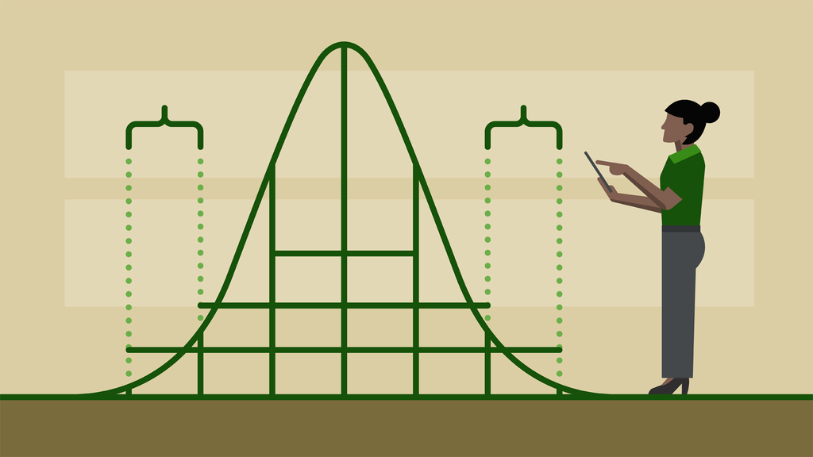

Source: https://cdn.lynda.com/course/495322/495322-636154038826424503-16x9.jpg

### Slides

- [Here are the introduction slides for this practical on statistics!](https://therbootcamp.github.io/BaselRBootcamp_2018April/_sessions/D2S2_Statistics/Statistics.html#1)

### Overview

In this practical you’ll do basic statistics in R. By the end of this practical you will know how to:

1. Calculate basic descriptive statistics using `mean()`, `median()`, `table()`.
2. Conduct 1 and 2 sample hypothesis tests with `t.test()`, `cor.test()`
3. Calculate regression analyses with `glm()` and `lm()`
4. Explore statistical objects with `names()`, `summary()`, `print()`, `predict()`
5. Use sampling functions such as `rnorm()` to conduct simulations

### Packages

| Package | Installation |
| --- | --- |
| `tidyverse` | `install.packages("tidyverse")` |
| `lubridate` | `install.packages("lubridate")` |
| `broom` | `install.packages("broom")` |
| `rsq` | `install.packages("rsq")` |

### Datasets

| File | Rows | Columns | Description | Source |
| --- | --- | --- | --- | --- |
| `kc_house_data.csv` | 21613 | 21 | House sale prices for King County between May 2014 and May 2015. | [Kaggle: House Sales Prediction](https://www.kaggle.com/harlfoxem/housesalesprediction/home) |

### Glossary

*Descriptive Statistics*

| Function | Description |
| --- | --- |
| `table()` | Frequency table |
| `mean(), median(), mode()` | Measures of central tendency |
| `sd(), range(), var()` | Measures of variability |
| `max(), min()` | Extreme values |
| `summary()` | Several summary statistics |

*Statistical Tests*

| Function | Hypothesis Test |
| --- | --- |
| `t.test()` | One and two sample t-test |
| `cor.test()` | Correlation test |
| `glm()`, `lm()` | Generalized linear model and linear model |

*Sampling Functions*

| Function | Description | Additional Help |
| --- | --- | --- |
| `sample()` | Draw a random sample of values from a vector | `?sample` |
| `rnorm()` | Draw random values from a Normal distribution | `?rnorm()` |
| `runif` | Draw random values from a Uniform distribution | `?runif()` |

### Example Code

```r
# -----------------------------------------------
# Examples of hypothesis tests on the diamonds
# ------------------------------------------------
library(tidyverse)
library(broom)
library(rsq)

# First few rows of the diamonds data

diamonds

# -----
# Descriptive statistics
# -----

mean(diamonds$carat)   # What is the mean carat?
median(diamonds$price)   # What is the median price?
max(diamonds$depth)    # What is the maximum depth?
table(diamonds$color)    # How many observations for each color?

# -----
# 1-sample hypothesis test
# -----

# Q: Is the mean carat of diamonds different from .50?

htest_A <- t.test(x = diamonds$carat,     # The data
                  alternative = "two.sided",  # Two-sided test
                  mu = 0.5)                   # The null hyopthesis

htest_A            # Print result
names(htest_A)     # See all attributes in object
htest_A$statistic  # Get just the test statistic
htest_A$p.value    # Get the p-value
htest_A$conf.int   # Get a confidence interval

# -----
# 2-sample hypothesis test
# -----

# Q: Is there a difference in the carats of color = E and color = I diamonds?

htest_B <- t.test(formula = carat ~ color,     # DV ~ IV
                   alternative = "two.sided",  # Two-sided test
                   data = diamonds,         # The data
                   subset = color %in% c("E", "I")) # Compare Diet 1 and Diet 2

htest_B  # Print result

# -----
# Correlation test
# ------

# Q: Is there a correlation between carat and price?

htest_C <- cor.test(formula = ~ carat + price,
                    data = diamonds)

htest_C

# A: Yes. r = 0.92, t(53938) = 551.51, p < .001

# -----
# Regression
# ------

# Q: Create regression equation predicting price by carat, depth, table, and x

price_glm <- glm(formula = price ~ carat + depth + table + x,
                  data = diamonds)

# Print coefficients
price_glm$coefficients

# Tidy version
tidy(price_glm)

# Extract R-Squared
rsq(price_glm)

# -----
# Simulation
# ------

# 100 random samples from a normal distribution with mean = 0, sd = 1
samp_A <- rnorm(n = 100, mean = 0, sd = 1)

# 100 random samples from a Uniform distribution with bounds at 0, 10
samp_B <- runif(n = 100, min = 0, max = 10)

# Calculate descriptives
mean(samp_A)
sd(samp_A)

mean(samp_B)
sd(samp_B)

# Combine samples (plus tw new ones) in a tibble

my_sim <- tibble(A = samp_A,
                 B = samp_B,
                 C = rnorm(n = 100, mean = 0, sd = 1),
                 error = rnorm(n = 100, mean = 5, sd = 10))

# Add y, a linear function of A and B to my_sim
my_sim <- my_sim %>%
  mutate(y = 3 * A -8 * B + error)

# Regress y on A, B and C
my_glm <- glm(y ~ A + B + C,
              data = my_sim)

# Look at results!
tidy(my_glm)
```

# Tasks

### Getting setup

A. Open your R project. It should already have the folders `0_Data` and `1_Code`. Make sure that all of the data files listed above are contained in the folder

C. For this practical, we’ll use the `kc_house_data.csv` data. This dataset contains house sale prices for King County, Washington. It includes homes sold between May 2014 and May 2015. Using the following template, load the data into R and store it as a new object called `kc_house`.

```r
kc_house <- read_csv(file = "data/kc_house_data.csv")
```

C. Using `print()`, `summary()`, `head()` and `skim()`, explore the data to make sure it was loaded correctly.

### Descriptive statistics

1. What was the mean price (`price`) of all houses?
2. What was the median price (`price`) of all houses?
3. What was the standard deviation price (`price`) of all houses?
4. What were the minimum and maximum prices? Try using `min()`, `max()`, and `range()`
5. How many houses were on the waterfront (`waterfront`) and how many were not? (Hint: use `table()`)

### T tests with t.test()

6. Do houses on the waterfront sell for more than those not on the waterfront? Answer this by creating an object called `water_htest` which contains the result of the appropriate t-test using `t.test()`. Use the following template

```r
water_htest <- t.test(formula = XX ~ XX,
                      data = XX)
```

- Print your `water_htest` object to see summary results
- Apply the `summary()` function to `water_htest`. Do you see anything new or important?
- Look at the names of the `water_htest` with `names()`. What are the named elements of the object?
- Using the `$` operator, print the exact test statistic of the t-test.
- Again using the `$` operator, print the exact p-value of the test.
- Use the `tidy()` function to return a dataframe containing the main results of the test.
7. Do houses on the waterfront also tend to have more (or less) living space (`sqft_living`)? Answer this by conducting the appropriate t-test and going through the same steps you did in the previous question

### Correlation tests with cor.test()

8. Do newer houses tend to sell for more than older houses? Answer this by creating an object called `time_htest` which contains the result of the appropriate correlation test using `cor.test()`. Use the following template:

```r
# Note: cor.terst() is the only function (we know of)
#  that uses formulas in the strange format
#   formula = ~ X + Y instead of formula = Y ~ X

time_htest <- cor.test(formula = ~ XX + XX,
                       data = XX)
```

- Print your `time_htest` object to see summary results
- Apply the `summary()` function to `time_htest`. Do you see anything new or important?
- Look at the names of the `time_htest` with `names()`. What are the named elements of the object?
- Using the `$` operator, print the exact correlation of the test.
- Again using the `$` operator, print the exact p-value of the test.
- Use the `tidy()` function to return a dataframe containing the main results of the test.
- Use the `rsq()` function to obtain the R-squared value.
9. Do houses in in better overall condition `condition` tend to sell at higher prices than those in worse condition? Answer this by conducting the appropriate correlation test and going through the same steps you did in the previous question.

### Linear Regression with lm() and glm()

10. In the previous question, you used a correlation test to see if newer houses tend to sell for more than older houses. Now let’s repeat the same analysis using a regression analsis with `lm()`. Do to this, use the following template:

```r
time_lm <- lm(formula = XX ~ XX,
                 data = XX)
```

- Print your `time_lm` object to see the main results.
- Use the `tidy()` function (from the `broom` package) to return a dataframe containing the main results of the test.
- How does the p-value of this test compare to what you got in the previous question when you used `cor.test()`?
11. Which of the variables `bedrooms`, `bathrooms`, and `sqft_living` predict housing price? Answer this by conducting the appropriate regression analysis using `lm()` and assigning the result to an object `price_lm`. Use the following template:

```r
price_lm <- lm(formula = XX ~ XX + XX + XX,
                 data = XX)
```

- Print your `price_glm` object to see the main results.
- Apply the `summary()` function to `price_glm`. Do you see anything new or important?
- Look at the names of the `price_glm` with `names()`. What are the named elements of the object?
- Using the `$` operator, print a vector of the estimated coefficients of the analysis.
- Use the `tidy()` function (from the `broom` package) to return a dataframe containing the main results of the test.
- Use the `rsq()` function (from the `rsq` package) to obtain the R-squared value. Does this match what you saw in your previous outputs?
12. Using the following template, create a new model called `everything_lm` that predicts housing prices based on *all* predictors in `kc_house` *except* for `id` and `date` (`id` is meaningless and date shouldn’t matter). Use the following template. Note that to include all predictors, we’ll use the `formula = y ~.` shortcut. We’ll also remove id and date from the dataset using `select()` before running the analysis.

```r
everything_lm <- lm(formula = XX ~.,
                    data = kc_house %>%
                             select(-id, -date))
```

- Print your `everything_lm` object to see the main results.
- Apply the `summary()` function to `everything_lm`. Do you see anything new or important?
- Using the `$` operator, print a vector of the estimated coefficients of the analysis. Are the beta values for bedrooms, bathrooms, and sqft_living different from what you got in your previous analysis `price_lm`?
- Use the `tidy()` function to return a dataframe containing the main results of the test.
- Use the `rsq()` function (from the `rsq` package) to obtain the R-squared value. How does this R-squared value compare to what you got in your previous regression `price_lm`?
13. How well did the `everything_lm` model fit the actual housing prices? We can answer this by calculating the average difference between the fitted values and the true values directly. Using the following template, make this calculation. What do you find is the mean absolute difference between the fitted housing prices and the true prices?

```r
# True housing prices
prices_true <- kc_house$XX

# Model fits (fitted.values)
prices_fitted <- everything_lm$XX

# Calculate absolute error between fitted and true values
abs_error <- abs(XX - XX)

# Calculate mean absolute error
mae <- mean(XX)

# Print the result!
mae
```

14. Using the following template, create a scatterplot showing the relationship between the fitted values of the `everything_lm` object and the true prices.

```r
# Create dataframe containing fitted and true prices
prices_results <- tibble(truth = XX,
                         fitted = XX)

# Create scatterplot
ggplot(data = prices_results,
       aes(x = fitted, y = truth)) +
  geom_point(alpha = .1) +
  geom_smooth(method = 'lm') +
  labs(title = "Fitted versus Predicted housing prices",
       subtitle = paste0("Mean Absolute Error = ", mae),
       caption = "Source: King County housing price Kaggle dataset",
       x = "Fitted housing price values",
       y = 'True values') +
  theme_minimal()
```